# **🧩 Phase – 1: Data Understanding**

# **🎯 Overall Insight**

✅ **Higher Income**  
✅ **Higher Credit Card Spending**  
✅ **Higher / Existing Mortgage Values**

This suggests that **financially active**, **higher-earning**, and **credit-engaged** customers are more likely to accept personal loans.

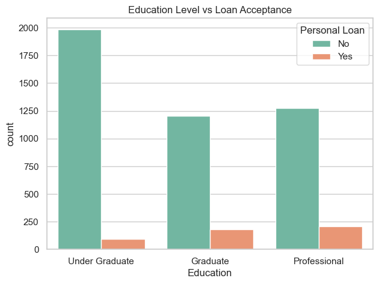

```python
plt.figure(figsize=(7,5))
sns.countplot(x='Education', hue='Personal Loan', data=df, palette='Set2')
plt.title("Education Level vs Loan Acceptance")
plt.show()
```

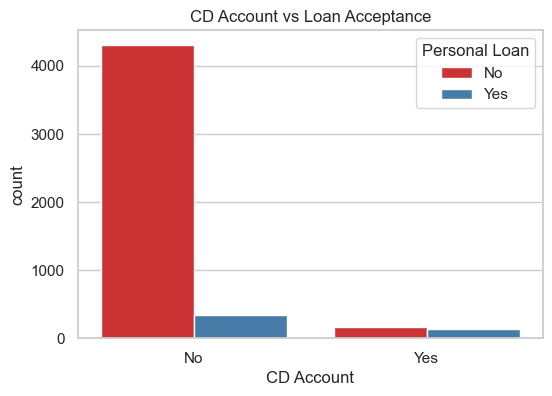

```python
plt.figure(figsize=(6,4))
sns.countplot(x='CD Account', hue='Personal Loan', data=df, palette='Set1')
plt.title("CD Account vs Loan Acceptance")
plt.show()
```

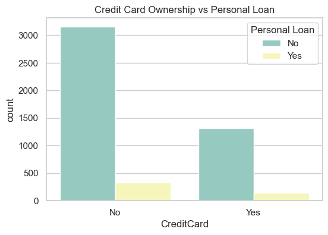

```python
plt.figure(figsize=(6,4))
sns.countplot(x='CreditCard', hue='Personal Loan', data=df, palette='Set3')
plt.title("Credit Card Ownership vs Personal Loan")
plt.show()
```

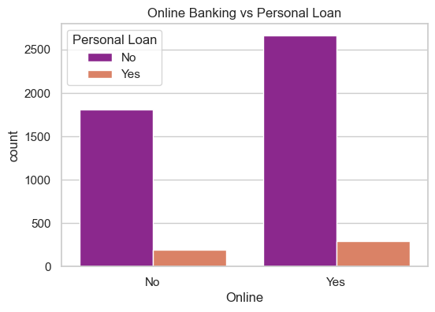

```python
plt.figure(figsize=(6,4))
sns.countplot(x='Online', hue='Personal Loan', data=df, palette='plasma')
plt.title("Online Banking vs Personal Loan")
plt.show()
```

# **📊 Observations – Categorical Features vs Personal Loan**

## **✅ 1. Education Level vs Personal Loan Acceptance**

- **Under Graduates** have the **lowest loan acceptance rate**.
- **Graduates** and **Professionals** show higher acceptance, with **Professionals** being slightly more likely to take loans.
- Customers with **higher education levels** display **greater interest** in personal loans.

📝 **Reason:** Higher education often correlates with **higher income**, **greater financial awareness**, and **more confidence** in using credit.

## **✅ 2. CD Account vs Personal Loan**

- Customers **without a CD Account** mostly said **No** to the personal loan.
- Those **with a CD Account** show a much **higher acceptance rate**.

📝 **Reason:** CD Account holders are typically **financially stronger**, more **trustworthy**, and have a **better relationship** with the bank — making them more likely to use loan products.

## **✅ 4. Online Banking Usage vs Personal Loan**

- Both **Online** and **Offline** customers mostly said **No** (because overall acceptance is only 9.6%).
- However, **Online users** have a **slightly higher** acceptance rate.

📝 **Reason:** Online customers are more **digitally active**, frequently see loan-related notifications, and respond more often to offers.

# **🎯 Overall Insight: Categorical Relationship**

Across all categorical features, customers who demonstrate:

are **more likely to accept a personal loan**.

# **📊 Visual Multi - Variate Analysis Using Correlation Heatmap**

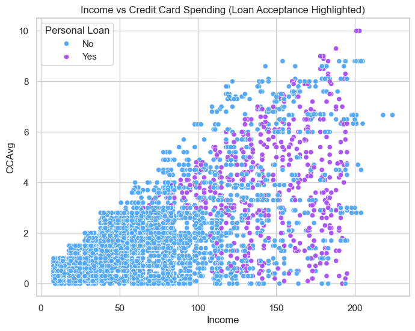

```python
plt.figure(figsize=(8,6))
sns.scatterplot(x='Income', y='CCAvg', hue='Personal Loan', data=df, palette='cool')
plt.title("Income vs Credit Card Spending (Loan Acceptance Highlighted)")
plt.show()
```

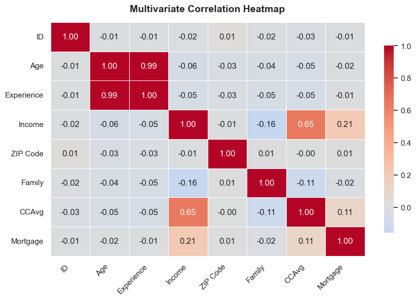

```python
num_cols = df.select_dtypes(include=['int64', 'float64'])

# Compute correlation matrix
corr = num_cols.corr()

# Plot heatmap
plt.figure(figsize=(10, 6))
sns.set(style="whitegrid")
sns.heatmap(corr, annot=True, cmap="coolwarm", center=0,
            fmt=".2f", linewidths=0.5, cbar_kws={'shrink': 0.8})
plt.title("Multivariate Correlation Heatmap", fontsize=14, weight='bold', pad=15)
plt.xticks(rotation=45, ha='right')
plt.yticks(rotation=0)
plt.show()
```

# **✅ Observations – Income vs Credit Card Spending (Loan Acceptance Highlighted)**

## **🔍 1. Strong Positive Trend**

- There is a clear **upward relationship** between **Income** and **Credit Card Spending (CCAvg)**.
- As **income increases**, customers tend to **spend more** on their credit cards.
- This reflects **normal financial behavior**, where high-income customers have higher purchasing power.

## **🔍 2. Clear Separation Between Loan Acceptors and Non-Acceptors**

- Loan **acceptors (“Yes”)** are mostly concentrated in the **upper-right region** of the plot  
  ➜ **High income + High spending**.
- Loan **non-acceptors (“No”)** are mostly clustered in the **lower-left region**  
  ➜ **Low income + Low spending**.
- This separation visually confirms that **financial strength** influences loan acceptance.

## **🔍 3. Loan Acceptance Strongly Linked to Financial Activity**

Loan acceptors tend to have:

- **Higher incomes**
- **Higher credit-card spending**
- **More financial activity and engagement**

These customers are generally:

- More **credit-reliable**
- More **active with financial products**
- More likely to **accept personal loans**

## **🔍 4. No Significant Outliers or Anomalies**

- The scatterplot shows **consistent and realistic values**.
- A few high points in the top-right are **genuine high-income, high-spending customers**, not anomalies.
- No invalid or unrealistic values appear.

# **✅ Overall Interpretation**

Customers who accept personal loans typically:

✅ **Earn more**  
✅ **Spend more**  
✅ **Show higher financial activity**

This supports the insight that **income** and **credit-card spending behavior** are **strong indicators** of personal-loan acceptance.

# **📊 Observations from Correlation Heatmap**

The **correlation heatmap** helps identify relationships between numerical features in the dataset — highlighting which variables move together and which remain independent.

## **🔍 Key Observations**

- **Age ↔ Experience:**
  - Correlation ≈ **0.99 (almost perfect positive)**

  ➤ As **age increases**, **work experience** also increases — a natural relationship.  
  ⚠️ Because of such a high correlation, using both features in a predictive model can cause **multicollinearity**.
- **Income ↔ CCAvg (Credit Card Average Spending):**
  - Correlation ≈ **0.65 (moderately strong positive)**

  ➤ Customers with **higher incomes** tend to **spend more on their credit cards**.
- **Income ↔ Mortgage:**
  - Correlation ≈ **0.21 (weak positive)**

  ➤ **Higher-income individuals** are slightly more likely to have **larger mortgages**.
- **Other correlations are weak or negligible:**
  - **Family ↔ Income:** –0.16
  - **Age ↔ CCAvg:** –0.05
  - **ZIP Code ↔ any variable:** ~0

  ➤ These indicate most features are **independent** and don’t strongly affect one another.
- No **strong negative correlations** were found — meaning no variable shows an opposite trend against another.

## **💡 Final Insights**

- The dataset is **mostly clean and non-redundant**, except for **Age** and **Experience**, which carry **nearly identical information**.  
  ➤ For modeling or EDA, it’s better to **keep only one** (commonly “Experience”) to avoid redundancy.
- **Income** and **CCAvg** emerge as **key behavioral indicators**, showing a strong connection to **financial activity** and likely influencing **personal loan acceptance**. 🚀

# **✅ Overall Project Summary – Thera Bank Personal Loan Modelling**

This project involved a complete **end-to-end analysis** of the **Thera Bank Personal Loan Modelling Dataset** to understand customer behavior and identify the key factors influencing **personal loan acceptance**.  
The dataset contains information about **5,000 customers**, covering demographics, income, spending patterns, and banking relationships.

The project was executed in three major phases:  
**Phase 1: Data Understanding**, **Phase 2: Data Cleaning & Preparation**, and **Phase 3: Exploratory Data Analysis (EDA)**.

# **📌 Phase 1: Data Understanding**

- Explored the dataset structure, column meanings, and variable types.
- Confirmed **14 well-defined features** with **no missing or duplicate records**.
- Examined basic statistics using `.describe()`, `.info()`, and distribution checks.
- Identified influential attributes such as **Income**, **CCAvg**, **Mortgage**, and **Education Level**.

### **✅ Outcome**

Gained a strong understanding of the dataset, including distributions, skewness, and potential factors influencing loan acceptance.

# **📌 Phase 2: Data Cleaning & Preparation**

### **✅ Outcome**

A fully clean, logically consistent, and analysis-ready dataset prepared for deeper EDA.

# **📌 Phase 3: Exploratory Data Analysis (EDA)**

## **1. Numerical Features vs Personal Loan**

- Loan acceptors have **higher Income**, **higher CCAvg**, and **higher Mortgage values**.
- Customers with lower financial activity mostly refused the loan.

## **3. Multivariate Analysis**

- **Income vs CCAvg** scatterplot showed a strong positive trend.
- Loan acceptance clusters were found in **high-income, high-spending** regions.
- Correlation heatmap highlighted meaningful interactions among financial variables.

### **✅ Outcome**

# **🎯 Final Conclusion**

The analysis shows that customers who are:

✅ **Financially active**  
✅ **Digitally engaged**  
✅ **Higher-income earners**  
✅ **Better educated**

are significantly more likely to accept a personal loan.

Thera Bank can use these insights to:

- Improve and focus marketing campaigns
- Target high-income, high-spending, and financially engaged customers
- Personalize offers for credit-active users
- Increase loan conversion rates effectively

✅ The cleaned dataset and extracted insights are ready for the next phase — **predictive modeling or building a loan acceptance classifier**. 🚀